# Extended Figures 5 to 7

- Show All Code
- Hide All Code
- View Source

Author

Joanny Raby

Extended Figures 5 and 7 correspond to Section 2. Extended Figure 6 is first mentioned in the second results section of the paper, but its content primarily relates to Section 3.

These figures are separate for page size reason, to keep a reasonable loading time.

The formatting of the figures may differ slightly from those in the paper, but they display the same data points.

All code cells are folded by default. To view any cell, click **“Code”** to expand it, or use the code options near the main title above to unfold all at once.

Some code may be repeated, as the original Python notebook was designed for figures to be generated semi-independently.

## Setup Code - Imports and co.

Setup imports.

```python
from __future__ import annotations

import itertools
import re
import tarfile
from pathlib import Path
from typing import Dict, List, Sequence

import numpy as np
import pandas as pd
import plotly.express as px
import plotly.graph_objects as go
from IPython.display import display
from plotly.subplots import make_subplots
from scipy.stats import zscore
from sklearn.metrics import accuracy_score, f1_score

from epiclass.utils.notebooks.paper.paper_utilities import (
    ASSAY,
    ASSAY_MERGE_DICT,
    ASSAY_ORDER,
    BIOMATERIAL_TYPE,
    CELL_TYPE,
    LIFE_STAGE,
    SEX,
    IHECColorMap,
    MetadataHandler,
    SplitResultsHandler,
    create_mislabel_corrector,
    PathChecker
)

CORE7_ASSAYS = ASSAY_ORDER[0:7]
```

Setup paths.

```python
# Root path
base_dir = Path.home() / "Projects/epiclass/output/paper"
PathChecker.check_directory(base_dir)

# More precise
base_data_dir = base_dir / "data"
base_fig_dir = base_dir / "figures"
table_dir = base_dir / "tables"
metadata_dir = base_data_dir / "metadata"

official_metadata_dir = metadata_dir / "epiatlas" / "official"
PathChecker.check_directory(official_metadata_dir)

# alias
paper_dir = base_dir
```

Setup colors.

```python
IHECColorMap = IHECColorMap(base_fig_dir)
assay_colors = IHECColorMap.assay_color_map
cell_type_colors = IHECColorMap.cell_type_color_map
sex_colors = IHECColorMap.sex_color_map
```

Setup metadata and prediction files handlers.

```python
split_results_handler = SplitResultsHandler()

metadata_handler = MetadataHandler(paper_dir)
metadata_v2 = metadata_handler.load_metadata("v2")
metadata_v2_df = metadata_v2.to_df()
```

Setup figures general settings.

```python
main_title_settings = {
    "title":dict(
        automargin=True,
        x=0.5,
        xanchor="center",
        yanchor="top",
        y=0.98
        ),
    "margin":dict(t=50, l=10, r=10)
}
```

## Extended Figure 5

### a - MLP AUROC on various classification tasks

Extended Fig. 5a: Distribution of AUROC scores evaluated per training fold (dots) for each metadata category, reported without applying a prediction score threshold. Dashed lines represent means, solid lines the medians, boxes the quartiles, and whiskers the farthest points within 1.5× the interquartile range. For the AUROC graphs, see Fig. 2a,b section.

### b - chrY signal per sex: Average EpiRR z-score per assay

Load 10-fold cross-validation results.

```python
sex_10fold_dir = (
    base_data_dir
    / "training_results"
    / "dfreeze_v2"
    / "hg38_100kb_all_none"
    / f"{SEX}_1l_3000n"
    / "10fold-oversampling"
)
PathChecker.check_directory(sex_10fold_dir)

split_results: Dict[str, pd.DataFrame] = split_results_handler.read_split_results(
    sex_10fold_dir
)
concat_results_10fold: pd.DataFrame = split_results_handler.concatenate_split_results(split_results, depth=1)  # type: ignore
concat_results_10fold = split_results_handler.add_max_pred(concat_results_10fold)
concat_results_10fold = metadata_handler.join_metadata(concat_results_10fold, metadata_v2)
```

Load chrY signal values.

```python
chrY_dir = base_data_dir / "chrY" / "dfreeze_v2_stats"
PathChecker.check_directory(chrY_dir)

chrY_df = pd.read_csv(chrY_dir / "chrY_zscores.csv")
```

Merge previous dataframes.

```python
cross_val_analysis = pd.merge(
    concat_results_10fold,
    chrY_df,
    left_index=True,
    right_on="filename",
    suffixes=("", "_DROP")
    )
cross_val_analysis.drop(
    columns=[c for c in cross_val_analysis.columns if c.endswith("_DROP")], inplace=True
)
```

Define function `zscore_per_assay` to compute and graph the metric for each assay instead of globally.

```python
def zscore_per_assay(zscore_df: pd.DataFrame) -> None:
    """
    Plot the z-score distributions per assay.

    Does not include pval and raw tracks.

    Args:
        zscore_df: The dataframe with z-score data.
    """
    zscore_df = zscore_df.copy(deep=True)

    # Remove pval/raw tracks + rna unstranded
    zscore_df = zscore_df[~zscore_df["track_type"].isin(["pval", "raw", "Unique_raw"])]

    # Merge rna protocols
    zscore_df.replace({ASSAY: ASSAY_MERGE_DICT}, inplace=True)

    # Remove NAs
    metric_label = "chrY_zscore_vs_assay_w_track_exclusion"
    zscore_df = zscore_df[zscore_df[metric_label] != "NA"]

    assay_sizes = zscore_df[ASSAY].value_counts()
    assays = sorted(assay_sizes.index)

    x_title = "Sex z-score distributions per assay"
    fig = make_subplots(
        rows=1,
        cols=len(assays),
        shared_yaxes=True,
        x_title=x_title,
        y_title="z-score",
        horizontal_spacing=0.02,
        subplot_titles=[
            f"{assay_label} ({assay_sizes[assay_label]})" for assay_label in assays
        ],
    )

    for i, assay_label in enumerate(sorted(assays)):
        sub_df = zscore_df[zscore_df[ASSAY] == assay_label]

        hovertext = [
            f"{epirr}: z-score={z_score:.3f}, pred={pred:.3f}"
            for epirr, pred, z_score in zip(
                sub_df["EpiRR"],
                sub_df["Max pred"],
                sub_df[metric_label],
            )
        ]
        hovertext = np.array(hovertext)

        sub_df.reset_index(drop=True, inplace=True)
        y_values = sub_df[metric_label].values

        female_idx = np.argwhere((sub_df[SEX] == "female").values).flatten()
        male_idx = np.argwhere((sub_df[SEX] == "male").values).flatten()

        fig.add_trace(
            go.Box(
                name=assay_label,
                y=y_values[female_idx],
                boxmean=True,
                boxpoints="all",
                hovertemplate="%{text}",
                text=hovertext[female_idx],
                marker=dict(
                    size=2,
                    color=sex_colors["female"],
                    line=dict(width=0.5, color="black"),
                ),
                fillcolor=sex_colors["female"],
                line=dict(width=1, color="black"),
                showlegend=False,
                legendgroup="Female",
            ),
            row=1,
            col=i + 1,
        )

        fig.add_trace(
            go.Box(
                name=assay_label,
                y=y_values[male_idx],
                boxmean=True,
                boxpoints="all",
                hovertemplate="%{text}",
                text=hovertext[male_idx],
                marker=dict(
                    size=2, color=sex_colors["male"], line=dict(width=0.5, color="black")
                ),
                fillcolor=sex_colors["male"],
                line=dict(width=1, color="black"),
                showlegend=False,
                legendgroup="Male",
            ),
            row=1,
            col=i + 1,
        )

    # Add a dummy scatter plot for legend
    fig.add_trace(
        go.Scatter(
            x=[None],
            y=[None],
            mode="markers",
            name="Female",
            marker=dict(color=sex_colors["female"], size=20),
            showlegend=True,
            legendgroup="Female",
        )
    )
    fig.add_trace(
        go.Scatter(
            x=[None],
            y=[None],
            mode="markers",
            name="Male",
            marker=dict(color=sex_colors["male"], size=20),
            showlegend=True,
            legendgroup="Male",
        )
    )

    fig.update_xaxes(showticklabels=False)
    fig.update_yaxes(range=[-1.5, 3], showticklabels=True)

    fig.update_layout(
        height=750,
    )

    fig.show()
```

Graph zscore per assay.

```python
zscore_per_assay(cross_val_analysis)
```

[interactive chart not shown]

### c - Female/Male chrY signal z-score cluster separation

Define function `merged_assays_separation_distance` that computes and graphs the showing separation distance between male/female zscore clusters.

```python
def merged_assays_separation_distance(zscore_df: pd.DataFrame) -> None:
    """Complement to figure 2E, showing separation distance (mean, median)
    between male/female zscore clusters, for ChIP-seq (core7). Grouped by EpiRR.

    Args:
        zscore_df (pd.DataFrame): The dataframe with z-score data.
    """
    metric_label = "chrY_zscore_vs_assay_track"

    # Preprocessing
    zscore_df = zscore_df.copy(deep=True)
    zscore_df.replace({ASSAY: ASSAY_MERGE_DICT}, inplace=True)

    zscore_df = zscore_df[zscore_df[ASSAY].isin(CORE7_ASSAYS)]  # type: ignore

    # Remove pval/raw tracks
    zscore_df = zscore_df[~zscore_df["track_type"].isin(["pval", "raw"])]

    # Average chrY z-score values
    mean_chrY_values_df = zscore_df.groupby(["EpiRR", SEX]).agg(
        {metric_label: "mean", "Max pred": "mean"}
    )
    mean_chrY_values_df.reset_index(inplace=True)
    if not mean_chrY_values_df["EpiRR"].is_unique:
        raise ValueError("EpiRR is not unique.")

    mean_chrY_values_df.reset_index(drop=True, inplace=True)

    distances = {"mean": [], "median": []}
    min_preds = list(np.arange(0, 1.0, 0.01)) + [0.999]
    sample_count = []
    for min_pred in min_preds:
        subset_chrY_values_df = mean_chrY_values_df[
            mean_chrY_values_df["Max pred"] > min_pred
        ]
        sample_count.append(subset_chrY_values_df.shape[0])

        # Compute separation distances
        chrY_vals_female = subset_chrY_values_df[subset_chrY_values_df[SEX] == "female"][
            metric_label
        ]
        chrY_vals_male = subset_chrY_values_df[subset_chrY_values_df[SEX] == "male"][
            metric_label
        ]

        if not chrY_vals_female.empty and not chrY_vals_male.empty:
            mean_distance = np.abs(chrY_vals_female.mean() - chrY_vals_male.mean())
            median_distance = np.abs(chrY_vals_female.median() - chrY_vals_male.median())

            distances["mean"].append(mean_distance)
            distances["median"].append(median_distance)
        else:
            distances["mean"].append(np.nan)
            distances["median"].append(np.nan)

    # Plotting the results
    fig = go.Figure()

    # Add traces for mean and median distances
    fig.add_trace(
        go.Scatter(
            x=min_preds,
            y=distances["mean"],
            mode="lines+markers",
            name="Mean Distance (left)",
            line=dict(color="blue"),
        )
    )
    fig.add_trace(
        go.Scatter(
            x=min_preds,
            y=distances["median"],
            mode="lines+markers",
            name="Median Distance (left)",
            line=dict(color="green"),
        )
    )

    # Add trace for number of files
    fig.add_trace(
        go.Scatter(
            x=min_preds,
            y=np.array(sample_count) / max(sample_count),
            mode="lines+markers",
            name="Proportion of samples (right)",
            line=dict(color="red"),
            yaxis="y2",
        )
    )

    fig.update_xaxes(range=[0.499, 1.0])

    # Update layout for secondary y-axis
    fig.update_layout(
        title="Separation Distance of chrY z-scores male/female clusters - ChIP-Seq",
        xaxis_title="Average Prediction Score minimum threshold",
        yaxis_title="Z-score Distance",
        yaxis2=dict(title="Proportion of samples", overlaying="y", side="right"),
        yaxis2_range=[0, 1.001],
        legend=dict(
            x=1.08,
        ),
    )

    fig.show()
```

Graph.

```python
merged_assays_separation_distance(cross_val_analysis)
```

[interactive chart not shown]

Extended Fig. 5c: Effect of a prediction score threshold on the aggregated mean (blue) and median (green) sex z-score male/female cluster distances, as well as and corresponding file subset size (red) of ChIP-related assays from panel b.

### e - Epilogos sex genes chromatin states

Images extracted from Epilogos viewer, using specified coordinates (XIST and FIRRE positions), and:

- View mode: Paired
- Dataset: IHEC
- Pairwise: Male VS Female 100 samples
- Saliency Metric: S1

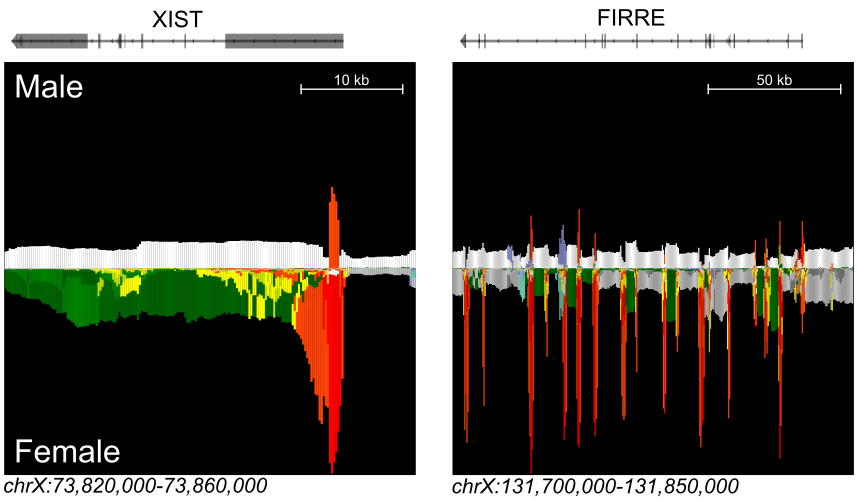

Extended Fig. 5e: Epilogos pairwise comparisons of male (top) vs female (bottom) showing portions of important regions for the Sex classifier, including the XIST (left) and FIRRE (right) genes.

See Annex A for a more detailled Epilogos color legend.

### f - Genome browser for biospecimen important regions

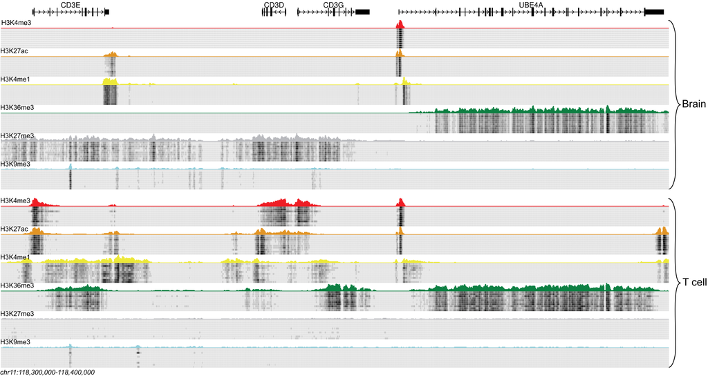

Extended Fig. 5f: Genome browser representation of the important regions shown in Fig. 2i.

### g - RNA-Seq read handling: Unique vs UniqueMultiple vs Unstranded

The RNA-Seq classifiers were trained on the **Unique** representation (multi-mapped reads excluded). This panel compares three read-handling variants of the same RNA samples on every non-assay task: **Unique**, **UniqueMultiple** (multi-mapped reads included) and **Unstranded (summed)** (the two Unique stranded tracks summed into one signal per EpiRR). Each fold’s model is applied to its held-out RNA validation set for the three variants, so the comparison is on samples the model did not train on and whose true label is in the classifier’s class space.

The predictions were produced by `src/python/epiclass/utils/notebooks/predictions/make_rna_read_handling_predictions.py`, which pairs the three variants per sample (resolving md5sums to EpiRRs and restricting to each fold’s validation set) and writes a long-form predictions table. Every prediction carries the Comet experiment key of the classifier that produced it. The figure below reads that table and scores Accuracy and macro-F1 per task, fold and variant.

```python
rna_variations_dir = base_data_dir / "rna_variations"
PathChecker.check_directory(rna_variations_dir)
# The file starts with a '#'-commented provenance header (metadata source of
# true_class, model identity); comment="#" skips it.
rna_preds = pd.read_csv(
    rna_variations_dir / "rna_read_handling_predictions.csv", comment="#"
)


def score_read_handling(group: pd.DataFrame) -> pd.Series:
    """Accuracy and macro-F1 of one (task, fold, variant) group vs the true label."""
    labels = sorted(group["true_class"].unique())
    return pd.Series(
        {
            "Accuracy": accuracy_score(group["true_class"], group["predicted_class"]),
            "F1_macro": f1_score(
                group["true_class"],
                group["predicted_class"],
                labels=labels,
                average="macro",
                zero_division=0,
            ),
        }
    )


rna_metrics = (
    rna_preds.groupby(["model", "split", "mapping"])
    .apply(score_read_handling)
    .reset_index()
)
```

```python
# Canonical task order + display names; assay is excluded (mRNA/total-RNA confusion
# is not relevant to this comparison).
TASK_ORDER = ["cancer", "life_stage", "sex", "cell_type", "biomaterial"]
TASK_LABELS = {
    "cancer": "Cancer status",
    "life_stage": "Life stage",
    "sex": "Sex",
    "cell_type": "Biospecimen",
    "biomaterial": "Biomaterial type",
}
MAPPINGS = ["Unique", "Unstranded (summed)", "UniqueMultiple"]
# Okabe-Ito colourblind-safe palette.
MAPPING_COLORS = {
    "Unique": "#0072B2",
    "UniqueMultiple": "#D55E00",
    "Unstranded (summed)": "#009E73",
}

metrics = rna_metrics[rna_metrics["model"] != "assay"]
present = set(metrics["model"])
task_order_labels = [TASK_LABELS[t] for t in TASK_ORDER if t in present]

fig = make_subplots(
    rows=1, cols=2, subplot_titles=["Accuracy", "F1_macro"], horizontal_spacing=0.08
)
for col, metric in enumerate(["Accuracy", "F1_macro"], start=1):
    for mapping in MAPPINGS:
        sub = metrics[metrics["mapping"] == mapping]
        fig.add_trace(
            go.Box(
                x=sub["model"].map(TASK_LABELS),
                y=sub[metric],
                name=mapping,
                fillcolor=MAPPING_COLORS[mapping],
                line=dict(color="black", width=1.2),
                marker=dict(size=3, color="white", line_width=1),
                boxmean=True,
                boxpoints="all",
                pointpos=0,
                # Show the fold each point comes from on hover (as in Fig. 2a,b).
                hovertemplate="%{text}",
                text=[
                    f"{split}: {value:.4f}"
                    for split, value in zip(sub["split"], sub[metric])
                ],
                legendgroup=mapping,
                showlegend=col == 1,
            ),
            row=1,
            col=col,
        )
fig.update_xaxes(categoryorder="array", categoryarray=task_order_labels)
# Semi auto-scaled: fix the top, let the bottom auto-scale to the data.
fig.update_yaxes(autorange="min", range=[None, 1.02], row=1, col=1)
fig.update_yaxes(autorange="min", range=[None, 1.02], row=1, col=2)
fig.update_layout(
    boxmode="group",
    template="plotly_white",
    yaxis_title="Value",
    height=550,
    width=1400,
    legend=dict(orientation="h", y=-0.15),
)
fig.show()
```

[interactive chart not shown]

Extended Fig. 5g: Accuracy and macro-F1 performance metrics using only RNA-seq datasets across three data types and five classifiers, which were trained exclusively on strand-specific signals. Each fold’s trained model was applied to its own validation samples (Unique, blue), after summing forward and reverse tracks (Unstranded, green), and on a different version of the RNA-seq data downloaded from EpiATLAS where multi-mapped reads were retained as for recount3 (UniqueMultiple, orange) used only for this particular analysis. Changes in Unstranded and UniqueMultiple relative to Unique correspond to the impact of the data type on the inference since the same trained model was applied to all three data types. Each point is the score from one of the 10 cross-validation folds, computed across all signal files in that fold’s validation set. Solid lines are medians, dashed lines means, boxes the quartiles, and whiskers the farthest points within 1.5× the interquartile range.

## Extended Figure 6 - Prediction score threshold impact

For full code, since the processing is more complex, see `src/python/epiclass/utils/notebooks/paper/confidence_threshold.ipynb` ([permalink](https://github.com/labjacquespe/EpiClass/blob/ef1f5448b59a40d2b5e823e78d61ca5337b4d099/src/python/epiclass/utils/notebooks/paper/confidence_threshold.ipynb)).

[interactive chart not shown]

Extended Fig. 6: Impact of prediction score threshold on accuracy, F1-score and number of files for both EpiATLAS cross-validation performance and inference on datasets from other databases with provided or extracted labels. Performance for Assay, Sex, Cancer, Biomaterial type and Life stage classifiers are shown, for EpiATLAS (a), ENCODE core/non-core (b-c), ChIP-Atlas (d) and recount3 (e) datasets. The number of classes (C) and the number of files analyzed (n) used to calculate the performances are shown at the bottom for each graph. The 11 classes of the Assay classifiers for EpiATLAS correspond to the six ChIP-seq histone modifications, their control Input file, and two protocols of both RNA-seq and WGBS, while for the 9 classes of ENCODE the two protocols were grouped, and indeed only the seven ChIP-related assays were used for ChIP-Atlas and RNA-seq for recount3. For the Sex classifier the third class corresponds to ‘mixed’, absent for ENCODE. The Cancer classifier is binary (where non-cancer is a mix of healthy and other diseases). For the Biomaterial classifier the primary_cell_culture class is missing from all public sources (but primary_cell, primary_tissue and cell_line are present), while the three classes (perinatal, pediatric, adult) were always used for the Life stage classifier.

## Extended Figure 7 - Biospecimen classifier - ChromScore for high-SHAP regions

For full code, since the processing is more complex, see `src/python/epiclass/utils/notebooks/paper/chromscore.ipynb` ([permalink](https://github.com/labjacquespe/EpiClass/blob/dde0ff56a5840936a1f853b867aae822e4db1259/src/python/epiclass/utils/notebooks/paper/chromscore.ipynb)).

This is the breakdown per cell type of Fig. 2g.

[interactive chart not shown]

## Annex A - Epilogos color legend

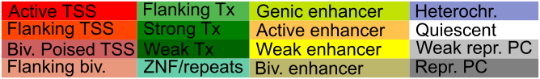

- biv = bivalent
- Tx = Transcription
- Repr = Repressed
- PC = Polycomb